# Multi-Layer Perceptron (MLP)

*A comprehensive guide to the foundational architecture of deep learning*

## Overview

The Multi-Layer Perceptron (MLP) is the foundational architecture of deep learning, consisting of multiple layers of interconnected artificial neurons. MLPs are universal function approximators that can learn complex non-linear mappings through the composition of simple linear transformations and non-linear activation functions.

### Why MLPs are Fundamental

MLPs serve as the building blocks for virtually all neural network architectures:

- **Fully Connected Layers** in CNNs and Vision Transformers
- **Feed-Forward Networks** in Transformers
- **Dense Layers** in hybrid architectures
- **Classification/Regression Heads** in most models

### Connection to Neural Network Components

An MLP combines multiple fundamental components:

- **Artificial Neurons**: Each node performs weighted sum + bias + activation
- **Activation Functions**: Non-linearities between layers enable complex mappings
- **Linear Transformations**: Matrix operations that transform feature spaces
- **Gradient-based Learning**: Backpropagation updates all layer weights simultaneously

## Mathematical Foundation

### MLP Architecture

An MLP with $L$ layers can be expressed as a composition of functions:

$$ \mathbf{y} = f_L(f_{L-1}(...f_2(f_1(\mathbf{x})))) $$

Where each layer $l$ performs: $$ \mathbf{h}^{(l)} = \sigma(\mathbf{W}^{(l)} \mathbf{h}^{(l-1)} + \mathbf{b}^{(l)}) $$

**Components:**

- $\mathbf{h}^{(l)} \in \mathbb{R}^{n_l}$: Hidden state of layer $l$
- $\mathbf{W}^{(l)} \in \mathbb{R}^{n_l \times n_{l-1}}$: Weight matrix for layer $l$
- $\mathbf{b}^{(l)} \in \mathbb{R}^{n_l}$: Bias vector for layer $l$
- $\sigma(\cdot)$: Element-wise activation function
- $n_l$: Number of neurons in layer $l$

### Universal Approximation Theorem

**Theorem**: An MLP with:

- At least one hidden layer
- Sufficient width (neurons)
- Non-linear activation functions

Can approximate any continuous function on a compact set to arbitrary accuracy.

### Parameter Count

For an MLP with layers $[n_0, n_1, ..., n_L]$:

$$ \text{Parameters} = \sum_{l=1}^{L} (n_{l-1} \times n_l + n_l) = \sum_{l=1}^{L} n_l(n_{l-1} + 1) $$

| **Layer Type** | **Input to Output** | **Parameters** |
| --- | --- | --- |
| **Hidden Layer** | $n_{in} \to n_{hidden}$ | $n_{in} \times n_{hidden} + n_{hidden}$ |
| **Output Layer** | $n_{hidden} \to n_{out}$ | $n_{hidden} \times n_{out} + n_{out}$ |

## 🧠 Core Concept: Hierarchical Logic of MLP Layers

This is the **fundamental insight** that makes MLPs intuitive to understand - each layer builds increasingly complex decision boundaries through logical operations:

### **The Layer-by-Layer Logic Construction**

```
Layer 1: HYPERPLANES        -> Linear decision boundaries (half-spaces)
Layer 2: AND operations     -> Convex hulls (intersections of hyperplanes)
Layer 3: OR operations      -> Multiply connected regions (unions of hulls)
Layer N: Complex logic      -> Arbitrary decision boundaries
```

### **Geometric and Logical Interpretation**

#### **Layer 1: Creating Hyperplanes**

- Each neuron: `ReLU(w·x + b)` defines a **half-space**
- Result: Collection of linear decision boundaries
- **Geometric**: Dividing input space with straight lines/planes
- **Logical**: Individual conditions ("x > threshold")

#### **Layer 2: AND Logic → Convex Hulls**

- Combines multiple hyperplanes: `ReLU(Σ wᵢ·hᵢ + b)`
- **Key Insight**: Activates only when **MULTIPLE** first-layer neurons are active
- **Geometric**: **Intersection** of half-spaces = **Convex regions**
- **Logical**: **AND** operations ("condition₁ AND condition₂ AND ...")

#### **Layer 3: OR Logic → Multiply Connected Regions**

- Combines convex hulls: `ReLU(Σ wⱼ·h₂ⱼ + b)`
- **Key Insight**: Activates when **ANY** of the convex regions is active
- **Geometric**: **Union** of convex regions = **Complex, non-convex shapes**
- **Logical**: **OR** operations ("hull₁ OR hull₂ OR ...")

#### **Deeper Layers: Hierarchical Refinement**

- Continue alternating AND/OR-like operations
- Build increasingly sophisticated decision boundaries
- Approach arbitrary complexity through logical composition

### **Why This Matters**

This hierarchical structure explains:

1. **Universal Approximation**: Any decision boundary can be built through hierarchical AND/OR operations
2. **Depth vs Width**: Deeper networks can represent exponentially more complex functions
3. **Feature Learning**: Each layer learns increasingly abstract geometric patterns
4. **Expressivity**: Why MLPs can solve complex non-linear problems

### **Intuitive Example**

Think of recognizing a "house":

- **Layer 1**: Detect edges, lines, corners (hyperplanes)
- **Layer 2**: Combine edges into shapes like "roof" or "door" (convex hulls via AND)
- **Layer 3**: Combine shapes into "house" concept (multiply connected via OR)

This geometric intuition makes the **universal approximation theorem** concrete: MLPs can build any decision boundary by hierarchically combining simple geometric primitives!

### 🎯 Visual Demonstration

The following diagram illustrates this hierarchical logic in action - showing how MLPs transform simple hyperplanes into complex decision boundaries through AND/OR operations:

```
=== Hierarchical Logic of MLP Layers ===
```

[output not shown]

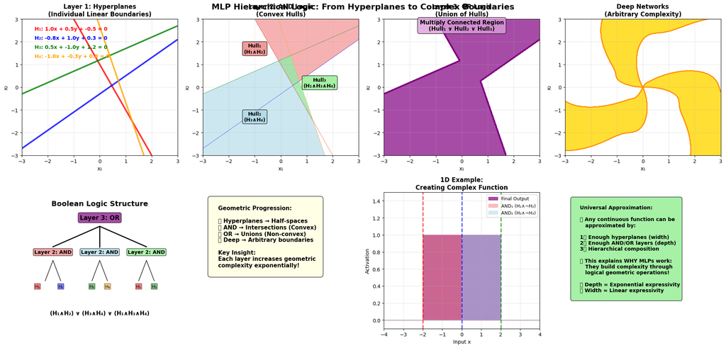

```python
def create_hierarchical_logic_diagram():
    """Visualize the hierarchical AND/OR logic of MLP layers"""

    fig, axes = plt.subplots(2, 4, figsize=(20, 10))
    fig.suptitle('MLP Hierarchical Logic: From Hyperplanes to Complex Boundaries',
                 fontsize=16, fontweight='bold', y=0.95)

    # Create input space
    x = np.linspace(-3, 3, 300)
    y = np.linspace(-3, 3, 300)
    X, Y = np.meshgrid(x, y)

    # === TOP ROW: Layer-by-Layer Construction ===

    # 1. Layer 1: Individual Hyperplanes
    ax = axes[0, 0]

    # Define 4 hyperplanes for demonstration
    hyperplanes = [
        (1, 0.5, -0.5, 'red', 'H₁'),      # x + 0.5y - 0.5 = 0
        (-0.8, 1, 0.3, 'blue', 'H₂'),     # -0.8x + y + 0.3 = 0
        (0.5, -1, 1.2, 'green', 'H₃'),    # 0.5x - y + 1.2 = 0
        (-1, -0.3, 0.8, 'orange', 'H₄')   # -x - 0.3y + 0.8 = 0
    ]

    # Plot each hyperplane
    for i, (w1, w2, b, color, label) in enumerate(hyperplanes):
        Z = w1 * X + w2 * Y + b
        ax.contour(X, Y, Z, levels=[0], colors=[color], linewidths=3, alpha=0.8)
        ax.text(-2.5, 2.5 - i*0.4, f'{label}: {w1:.1f}x + {w2:.1f}y + {b:.1f} = 0',
               color=color, fontsize=10, fontweight='bold')

    ax.set_title('Layer 1: Hyperplanes\n(Individual Linear Boundaries)',
                fontsize=12, fontweight='bold')
    ax.set_xlabel('x₁')
    ax.set_ylabel('x₂')
    ax.grid(True, alpha=0.3)
    ax.set_xlim(-3, 3)
    ax.set_ylim(-3, 3)

    # 2. Layer 2: AND Operations → Convex Hulls
    ax = axes[0, 1]

    # Create convex regions by combining hyperplanes (AND logic)
    convex_regions = []

    # Region 1: H1 AND H2 (intersection of two hyperplanes)
    Z1 = hyperplanes[0][0] * X + hyperplanes[0][1] * Y + hyperplanes[0][2]
    Z2 = hyperplanes[1][0] * X + hyperplanes[1][1] * Y + hyperplanes[1][2]
    region1 = (Z1 > 0) & (Z2 > 0)

    # Region 2: H3 AND H4
    Z3 = hyperplanes[2][0] * X + hyperplanes[2][1] * Y + hyperplanes[2][2]
    Z4 = hyperplanes[3][0] * X + hyperplanes[3][1] * Y + hyperplanes[3][2]
    region2 = (Z3 > 0) & (Z4 > 0)

    # Region 3: H1 AND H3 AND H4
    region3 = (Z1 > 0) & (Z3 > 0) & (Z4 > 0)

    # Plot regions with different colors
    ax.contourf(X, Y, region1.astype(int), levels=[0.5, 1.5], colors=['lightcoral'], alpha=0.6)
    ax.contourf(X, Y, region2.astype(int), levels=[0.5, 1.5], colors=['lightblue'], alpha=0.6)
    ax.contourf(X, Y, region3.astype(int), levels=[0.5, 1.5], colors=['lightgreen'], alpha=0.6)

    # Draw the original hyperplanes faintly
    for w1, w2, b, color, _ in hyperplanes:
        Z = w1 * X + w2 * Y + b
        ax.contour(X, Y, Z, levels=[0], colors=[color], linewidths=1, alpha=0.4)

    # Add region labels
    ax.text(-1, 1.5, 'Hull₁\n(H₁∧H₂)', ha='center', fontsize=10, fontweight='bold',
           bbox=dict(boxstyle="round,pad=0.3", facecolor='lightcoral', alpha=0.8))
    ax.text(-1, -1.5, 'Hull₂\n(H₃∧H₄)', ha='center', fontsize=10, fontweight='bold',
           bbox=dict(boxstyle="round,pad=0.3", facecolor='lightblue', alpha=0.8))
    ax.text(1.5, 0, 'Hull₃\n(H₁∧H₃∧H₄)', ha='center', fontsize=10, fontweight='bold',
           bbox=dict(boxstyle="round,pad=0.3", facecolor='lightgreen', alpha=0.8))

    ax.set_title('Layer 2: AND Logic\n(Convex Hulls)', fontsize=12, fontweight='bold')
    ax.set_xlabel('x₁')
    ax.set_ylabel('x₂')
    ax.grid(True, alpha=0.3)
    ax.set_xlim(-3, 3)
    ax.set_ylim(-3, 3)

    # 3. Layer 3: OR Operations → Multiply Connected
    ax = axes[0, 2]

    # Combine all convex regions (OR logic)
    combined_region = region1 | region2 | region3

    # Create a more complex multiply-connected region
    ax.contourf(X, Y, combined_region.astype(int), levels=[0.5, 1.5],
               colors=['purple'], alpha=0.7)

    # Draw boundaries
    ax.contour(X, Y, combined_region.astype(int), levels=[0.5],
              colors=['purple'], linewidths=3)

    ax.text(0, 2.5, 'Multiply Connected Region\n(Hull₁ ∨ Hull₂ ∨ Hull₃)',
           ha='center', fontsize=11, fontweight='bold',
           bbox=dict(boxstyle="round,pad=0.4", facecolor='plum', alpha=0.8))

    ax.set_title('Layer 3: OR Logic\n(Union of Hulls)', fontsize=12, fontweight='bold')
    ax.set_xlabel('x₁')
    ax.set_ylabel('x₂')
    ax.grid(True, alpha=0.3)
    ax.set_xlim(-3, 3)
    ax.set_ylim(-3, 3)

    # 4. Deep Networks: Hierarchical Refinement
    ax = axes[0, 3]

    # Simulate deeper network with more complex boundaries
    # Create a spiral-like pattern as example of complex decision boundary
    theta = np.arctan2(Y, X)
    r = np.sqrt(X**2 + Y**2)
    complex_boundary = np.sin(3*theta + r) + 0.3*np.sin(7*theta) > 0.2

    ax.contourf(X, Y, complex_boundary.astype(int), levels=[0.5, 1.5],
               colors=['gold'], alpha=0.8)
    ax.contour(X, Y, complex_boundary.astype(int), levels=[0.5],
              colors=['darkorange'], linewidths=2)

    ax.set_title('Deep Networks\n(Arbitrary Complexity)', fontsize=12, fontweight='bold')
    ax.set_xlabel('x₁')
    ax.set_ylabel('x₂')
    ax.grid(True, alpha=0.3)
    ax.set_xlim(-3, 3)
    ax.set_ylim(-3, 3)

    # === BOTTOM ROW: Mathematical Interpretation ===

    # 5. Boolean Logic Tree
    ax = axes[1, 0]
    ax.text(0.5, 0.9, 'Boolean Logic Structure', ha='center', fontsize=14,
           fontweight='bold', transform=ax.transAxes)

    # Draw logic tree
    ax.text(0.5, 0.8, 'Layer 3: OR', ha='center', fontsize=12, fontweight='bold',
           bbox=dict(boxstyle="round,pad=0.3", facecolor='purple', alpha=0.7),
           transform=ax.transAxes)

    # Draw connections
    ax.plot([0.5, 0.2], [0.75, 0.6], 'k-', linewidth=2, transform=ax.transAxes)
    ax.plot([0.5, 0.5], [0.75, 0.6], 'k-', linewidth=2, transform=ax.transAxes)
    ax.plot([0.5, 0.8], [0.75, 0.6], 'k-', linewidth=2, transform=ax.transAxes)

    ax.text(0.2, 0.55, 'Layer 2: AND', ha='center', fontsize=10, fontweight='bold',
           bbox=dict(boxstyle="round,pad=0.2", facecolor='lightcoral', alpha=0.7),
           transform=ax.transAxes)
    ax.text(0.5, 0.55, 'Layer 2: AND', ha='center', fontsize=10, fontweight='bold',
           bbox=dict(boxstyle="round,pad=0.2", facecolor='lightblue', alpha=0.7),
           transform=ax.transAxes)
    ax.text(0.8, 0.55, 'Layer 2: AND', ha='center', fontsize=10, fontweight='bold',
           bbox=dict(boxstyle="round,pad=0.2", facecolor='lightgreen', alpha=0.7),
           transform=ax.transAxes)

    # Draw more connections
    for x_pos in [0.2, 0.5, 0.8]:
        ax.plot([x_pos, x_pos-0.05], [0.5, 0.35], 'k-', linewidth=1, transform=ax.transAxes)
        ax.plot([x_pos, x_pos+0.05], [0.5, 0.35], 'k-', linewidth=1, transform=ax.transAxes)

    ax.text(0.1, 0.3, 'H₁', ha='center', fontsize=9,
           bbox=dict(boxstyle="round,pad=0.1", facecolor='red', alpha=0.5),
           transform=ax.transAxes)
    ax.text(0.25, 0.3, 'H₂', ha='center', fontsize=9,
           bbox=dict(boxstyle="round,pad=0.1", facecolor='blue', alpha=0.5),
           transform=ax.transAxes)
    ax.text(0.45, 0.3, 'H₃', ha='center', fontsize=9,
           bbox=dict(boxstyle="round,pad=0.1", facecolor='green', alpha=0.5),
           transform=ax.transAxes)
    ax.text(0.55, 0.3, 'H₄', ha='center', fontsize=9,
           bbox=dict(boxstyle="round,pad=0.1", facecolor='orange', alpha=0.5),
           transform=ax.transAxes)
    ax.text(0.75, 0.3, 'H₁', ha='center', fontsize=9,
           bbox=dict(boxstyle="round,pad=0.1", facecolor='red', alpha=0.5),
           transform=ax.transAxes)
    ax.text(0.85, 0.3, 'H₃', ha='center', fontsize=9,
           bbox=dict(boxstyle="round,pad=0.1", facecolor='green', alpha=0.5),
           transform=ax.transAxes)

    ax.text(0.5, 0.1, '(H₁∧H₂) ∨ (H₃∧H₄) ∨ (H₁∧H₃∧H₄)', ha='center', fontsize=11,
           fontweight='bold', transform=ax.transAxes)

    ax.set_xlim(0, 1)
    ax.set_ylim(0, 1)
    ax.axis('off')

    # 6. Geometric Progression
    ax = axes[1, 1]

    # Show progression from simple to complex
    progression_text = """
    Geometric Progression:

    🔸 Hyperplanes → Half-spaces
    🔸 AND → Intersections (Convex)
    🔸 OR → Unions (Non-convex)
    🔸 Deep → Arbitrary boundaries

    Key Insight:
    Each layer increases geometric
    complexity exponentially!
    """

    ax.text(0.05, 0.95, progression_text, fontsize=11, fontweight='bold',
           verticalalignment='top', transform=ax.transAxes,
           bbox=dict(boxstyle="round,pad=0.5", facecolor='lightyellow', alpha=0.8))

    ax.set_xlim(0, 1)
    ax.set_ylim(0, 1)
    ax.axis('off')

    # 7. 1D Intuitive Example
    ax = axes[1, 2]

    x_1d = np.linspace(-4, 4, 1000)

    # Create step functions representing hyperplanes in 1D
    h1 = np.where(x_1d > -2, 1, 0)  # Step at x = -2
    h2 = np.where(x_1d > 0, 1, 0)   # Step at x = 0
    h3 = np.where(x_1d > 2, 1, 0)   # Step at x = 2

    # Layer 2: AND combinations
    and1 = h1 * (1 - h2)  # h1 AND NOT h2: active between -2 and 0
    and2 = h2 * (1 - h3)  # h2 AND NOT h3: active between 0 and 2

    # Layer 3: OR combination
    final = and1 + and2  # OR of the two AND regions

    ax.fill_between(x_1d, 0, final, alpha=0.7, color='purple', label='Final Output')
    ax.fill_between(x_1d, 0, and1, alpha=0.5, color='lightcoral', label='AND₁ (H₁∧¬H₂)')
    ax.fill_between(x_1d, 0, and2, alpha=0.5, color='lightblue', label='AND₂ (H₂∧¬H₃)')

    # Mark hyperplane positions
    for pos, color in [(-2, 'red'), (0, 'blue'), (2, 'green')]:
        ax.axvline(pos, color=color, linestyle='--', alpha=0.7, linewidth=2)

    ax.legend(fontsize=9)
    ax.set_title('1D Example:\nCreating Complex Function', fontsize=12, fontweight='bold')
    ax.set_xlabel('Input x')
    ax.set_ylabel('Activation')
    ax.grid(True, alpha=0.3)
    ax.set_xlim(-4, 4)
    ax.set_ylim(-0.1, 1.5)

    # 8. Universal Approximation Insight
    ax = axes[1, 3]

    insight_text = """
    Universal Approximation:

    🧠 Any continuous function can be
       approximated by:

    1️⃣ Enough hyperplanes (width)
    2️⃣ Enough AND/OR layers (depth)
    3️⃣ Hierarchical composition

    🎯 This explains WHY MLPs work:
       They build complexity through
       logical geometric operations!

    📈 Depth ≈ Exponential expressivity
    📊 Width ≈ Linear expressivity
    """

    ax.text(0.05, 0.95, insight_text, fontsize=10, fontweight='bold',
           verticalalignment='top', transform=ax.transAxes,
           bbox=dict(boxstyle="round,pad=0.4", facecolor='lightgreen', alpha=0.8))

    ax.set_xlim(0, 1)
    ax.set_ylim(0, 1)
    ax.axis('off')

    plt.tight_layout()
    plt.show()

    return fig

# Create the hierarchical logic visualization
print("=== Hierarchical Logic of MLP Layers ===")
fig_logic = create_hierarchical_logic_diagram()
```

## MLP Architecture & Operations

Now let's see how the hierarchical logic translates into practical network architecture and operations:

```
=== MLP Architecture & Operations ===
```

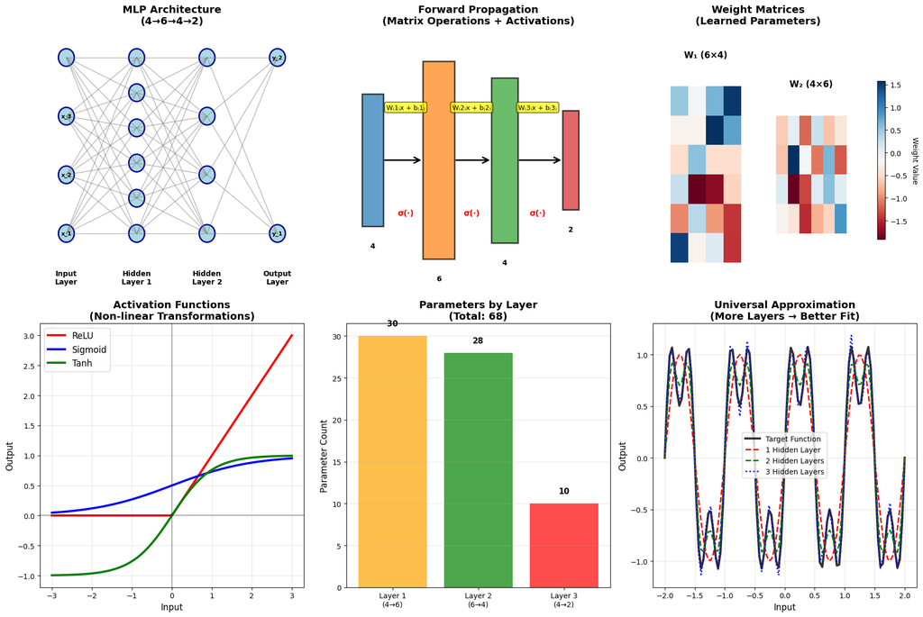

```python
import torch
import torch.nn as nn
import torch.nn.functional as F
import matplotlib.pyplot as plt
import numpy as np
from matplotlib.patches import Rectangle, Circle, FancyBboxPatch, ConnectionPatch
from matplotlib.colors import LinearSegmentedColormap
import matplotlib.patches as mpatches

def create_mlp_architecture_diagrams():
    """Create comprehensive diagrams showing MLP architecture and operations"""

    fig, axes = plt.subplots(2, 3, figsize=(18, 12))

    # 1. Basic MLP Architecture
    ax = axes[0, 0]

    # Define layer sizes
    layers = [4, 6, 4, 2]  # input, hidden1, hidden2, output
    layer_names = ['Input\nLayer', 'Hidden\nLayer 1', 'Hidden\nLayer 2', 'Output\nLayer']

    max_neurons = max(layers)
    layer_x_positions = np.linspace(1, 9, len(layers))

    # Draw neurons and connections
    neuron_positions = {}

    for layer_idx, (num_neurons, x_pos, name) in enumerate(zip(layers, layer_x_positions, layer_names)):
        y_positions = np.linspace(2, 8, num_neurons) if num_neurons > 1 else [5]
        neuron_positions[layer_idx] = []

        for neuron_idx, y_pos in enumerate(y_positions):
            # Draw neuron
            circle = Circle((x_pos, y_pos), 0.3, facecolor='lightblue',
                          edgecolor='darkblue', linewidth=2)
            ax.add_patch(circle)
            neuron_positions[layer_idx].append((x_pos, y_pos))

            # Add neuron labels for first few
            if layer_idx == 0 and neuron_idx < 3:
                ax.text(x_pos, y_pos, f'x_{neuron_idx+1}', ha='center', va='center',
                       fontsize=8, fontweight='bold')
            elif layer_idx == len(layers)-1:
                ax.text(x_pos, y_pos, f'y_{neuron_idx+1}', ha='center', va='center',
                       fontsize=8, fontweight='bold')

        # Add layer label
        ax.text(x_pos, 0.5, name, ha='center', va='center',
               fontsize=10, fontweight='bold')

    # Draw connections between layers
    for layer_idx in range(len(layers)-1):
        for start_pos in neuron_positions[layer_idx]:
            for end_pos in neuron_positions[layer_idx+1]:
                line = plt.Line2D([start_pos[0], end_pos[0]], [start_pos[1], end_pos[1]],
                                color='gray', alpha=0.6, linewidth=1)
                ax.add_line(line)

    ax.set_title('MLP Architecture\n(4→6→4→2)', fontsize=14, fontweight='bold')
    ax.set_xlim(0, 10)
    ax.set_ylim(0, 9)
    ax.axis('off')

    # 2. Forward Propagation Flow
    ax = axes[0, 1]

    # Show data flow through layers
    layer_widths = [0.8, 1.2, 1.0, 0.6]
    layer_heights = [2.0, 3.0, 2.5, 1.5]
    x_positions = [1, 3.5, 6, 8.5]

    for i, (width, height, x_pos) in enumerate(zip(layer_widths, layer_heights, x_positions)):
        # Draw layer as rectangle
        rect = Rectangle((x_pos-width/2, 4-height/2), width, height,
                        facecolor=f'C{i}', alpha=0.7, edgecolor='black', linewidth=2)
        ax.add_patch(rect)

        # Add dimensions
        ax.text(x_pos, 4-height/2-0.3, f'{layers[i]}', ha='center', va='center',
               fontsize=10, fontweight='bold')

        # Add arrows between layers
        if i < len(layer_widths)-1:
            arrow = mpatches.FancyArrowPatch((x_pos+width/2, 4),
                                           (x_positions[i+1]-layer_widths[i+1]/2, 4),
                                           arrowstyle='->', mutation_scale=20,
                                           color='black', linewidth=2)
            ax.add_patch(arrow)

            # Add operation labels
            op_x = (x_pos + x_positions[i+1]) / 2
            ax.text(op_x, 4.8, f'W₍{i+1}₎x + b₍{i+1}₎', ha='center', va='center',
                   fontsize=9, bbox=dict(boxstyle="round,pad=0.3", facecolor='yellow', alpha=0.7))
            ax.text(op_x, 3.2, f'σ(·)', ha='center', va='center',
                   fontsize=11, fontweight='bold', color='red')

    ax.set_title('Forward Propagation\n(Matrix Operations + Activations)', fontsize=14, fontweight='bold')
    ax.set_xlim(0, 10)
    ax.set_ylim(2, 6)
    ax.axis('off')

    # 3. Weight Matrix Visualization
    ax = axes[0, 2]

    # Show weight matrices between layers
    w1 = np.random.randn(6, 4)  # 6 neurons in hidden layer 1, 4 inputs
    w2 = np.random.randn(4, 6)  # 4 neurons in hidden layer 2, 6 inputs

    # Plot first weight matrix
    im1 = ax.imshow(w1, cmap='RdBu', aspect='auto', extent=[0, 2, 4, 7])
    ax.text(1, 7.5, 'W₁ (6×4)', ha='center', fontsize=12, fontweight='bold')

    # Plot second weight matrix
    im2 = ax.imshow(w2, cmap='RdBu', aspect='auto', extent=[3, 5, 4.5, 6.5])
    ax.text(4, 7, 'W₂ (4×6)', ha='center', fontsize=12, fontweight='bold')

    # Add colorbar
    cbar = plt.colorbar(im1, ax=ax, shrink=0.6)
    cbar.set_label('Weight Value', rotation=270, labelpad=15)

    ax.set_title('Weight Matrices\n(Learned Parameters)', fontsize=14, fontweight='bold')
    ax.set_xlim(-0.5, 5.5)
    ax.set_ylim(3.5, 8)
    ax.axis('off')

    # 4. Activation Function Effects
    ax = axes[1, 0]

    # Show different activation functions
    x = np.linspace(-3, 3, 100)
    activations = {
        'ReLU': np.maximum(0, x),
        'Sigmoid': 1 / (1 + np.exp(-x)),
        'Tanh': np.tanh(x)
    }

    colors = ['red', 'blue', 'green']
    for i, (name, y) in enumerate(activations.items()):
        ax.plot(x, y, color=colors[i], linewidth=3, label=name)

    ax.axhline(y=0, color='black', linestyle='-', alpha=0.3)
    ax.axvline(x=0, color='black', linestyle='-', alpha=0.3)
    ax.grid(True, alpha=0.3)
    ax.legend(fontsize=12)
    ax.set_xlabel('Input', fontsize=12)
    ax.set_ylabel('Output', fontsize=12)
    ax.set_title('Activation Functions\n(Non-linear Transformations)', fontsize=14, fontweight='bold')

    # 5. Parameter Count Analysis
    ax = axes[1, 1]

    # Calculate parameters for each layer
    layer_pairs = [(layers[i], layers[i+1]) for i in range(len(layers)-1)]
    param_counts = [n_in * n_out + n_out for n_in, n_out in layer_pairs]
    layer_labels = [f'Layer {i+1}\n({n_in}→{n_out})' for i, (n_in, n_out) in enumerate(layer_pairs)]

    bars = ax.bar(range(len(param_counts)), param_counts,
                  color=['orange', 'green', 'red'], alpha=0.7)

    # Add value labels on bars
    for bar, count in zip(bars, param_counts):
        height = bar.get_height()
        ax.text(bar.get_x() + bar.get_width()/2., height + 1,
               f'{count}', ha='center', va='bottom', fontsize=11, fontweight='bold')

    ax.set_xticks(range(len(layer_labels)))
    ax.set_xticklabels(layer_labels)
    ax.set_ylabel('Parameter Count', fontsize=12)
    ax.set_title(f'Parameters by Layer\n(Total: {sum(param_counts)})', fontsize=14, fontweight='bold')
    ax.grid(True, alpha=0.3, axis='y')

    # 6. Universal Approximation Visualization
    ax = axes[1, 2]

    # Show how MLPs can approximate complex functions
    x = np.linspace(-2, 2, 100)
    target_function = np.sin(2*np.pi*x) + 0.5*np.sin(6*np.pi*x)

    # Simulate MLP approximations with different complexities
    mlp_1_layer = np.sin(2*np.pi*x)  # Simple approximation
    mlp_2_layer = np.sin(2*np.pi*x) + 0.3*np.sin(6*np.pi*x)  # Better approximation
    mlp_3_layer = target_function + 0.05*np.random.randn(len(x))  # Close approximation

    ax.plot(x, target_function, 'k-', linewidth=3, label='Target Function', alpha=0.8)
    ax.plot(x, mlp_1_layer, 'r--', linewidth=2, label='1 Hidden Layer')
    ax.plot(x, mlp_2_layer, 'g--', linewidth=2, label='2 Hidden Layers')
    ax.plot(x, mlp_3_layer, 'b:', linewidth=2, label='3 Hidden Layers')

    ax.legend(fontsize=10)
    ax.grid(True, alpha=0.3)
    ax.set_xlabel('Input', fontsize=12)
    ax.set_ylabel('Output', fontsize=12)
    ax.set_title('Universal Approximation\n(More Layers → Better Fit)', fontsize=14, fontweight='bold')

    plt.tight_layout()
    plt.show()

    return fig

# Create MLP architecture diagrams
print("=== MLP Architecture & Operations ===")
fig = create_mlp_architecture_diagrams()
```

## Modular MLP Implementation

Let's build MLPs using PyTorch's modular approach with clean class structures and proper entry points.

```python
import torch
import torch.nn as nn
import torch.optim as optim
import torch.nn.functional as F
from torch.utils.data import DataLoader, TensorDataset
import matplotlib.pyplot as plt
import numpy as np

class MLP(nn.Module):
    """
    Modular Multi-Layer Perceptron implementation

    Args:
        input_size (int): Number of input features
        hidden_sizes (list): List of hidden layer sizes
        output_size (int): Number of output units
        activation (str): Activation function ('relu', 'tanh', 'gelu', 'swish')
        dropout_rate (float): Dropout probability (0.0 to disable)
        use_batch_norm (bool): Whether to use batch normalization
        bias (bool): Whether to use bias in linear layers
    """

    def __init__(self, input_size, hidden_sizes, output_size,
                 activation='relu', dropout_rate=0.0, use_batch_norm=False, bias=True):
        super(MLP, self).__init__()

        self.input_size = input_size
        self.hidden_sizes = hidden_sizes
        self.output_size = output_size
        self.activation_name = activation

        # Build layers
        self.layers = self._build_layers(input_size, hidden_sizes, output_size,
                                       activation, dropout_rate, use_batch_norm, bias)

        # Initialize weights
        self._initialize_weights()

    def _build_layers(self, input_size, hidden_sizes, output_size,
                     activation, dropout_rate, use_batch_norm, bias):
        """Build the network layers"""
        layers = nn.ModuleList()

        # Input to first hidden layer
        prev_size = input_size

        # Hidden layers
        for hidden_size in hidden_sizes:
            # Linear transformation
            layers.append(nn.Linear(prev_size, hidden_size, bias=bias))

            # Batch normalization
            if use_batch_norm:
                layers.append(nn.BatchNorm1d(hidden_size))

            # Activation function
            layers.append(self._get_activation(activation))

            # Dropout
            if dropout_rate > 0:
                layers.append(nn.Dropout(dropout_rate))

            prev_size = hidden_size

        # Output layer (no activation, dropout, or batch norm)
        layers.append(nn.Linear(prev_size, output_size, bias=bias))

        return layers

    def _get_activation(self, activation):
        """Get activation function by name"""
        activations = {
            'relu': nn.ReLU(),
            'tanh': nn.Tanh(),
            'sigmoid': nn.Sigmoid(),
            'gelu': nn.GELU(),
            'swish': nn.SiLU(),  # SiLU is Swish
            'leaky_relu': nn.LeakyReLU(0.01),
            'elu': nn.ELU()
        }
        return activations.get(activation, nn.ReLU())

    def _initialize_weights(self):
        """Initialize network weights using Xavier/He initialization"""
        for layer in self.layers:
            if isinstance(layer, nn.Linear):
                if self.activation_name in ['relu', 'leaky_relu', 'elu']:
                    # He initialization for ReLU-like activations
                    nn.init.kaiming_normal_(layer.weight, mode='fan_in', nonlinearity='relu')
                else:
                    # Xavier initialization for other activations
                    nn.init.xavier_normal_(layer.weight)

                if layer.bias is not None:
                    nn.init.constant_(layer.bias, 0)

    def forward(self, x):
        """Forward pass through the network"""
        for layer in self.layers:
            x = layer(x)
        return x

    def get_architecture_info(self):
        """Get detailed architecture information"""
        total_params = sum(p.numel() for p in self.parameters())
        trainable_params = sum(p.numel() for p in self.parameters() if p.requires_grad)

        info = {
            'architecture': f"MLP({self.input_size} → {' → '.join(map(str, self.hidden_sizes))} → {self.output_size})",
            'total_parameters': total_params,
            'trainable_parameters': trainable_params,
            'activation': self.activation_name,
            'depth': len(self.hidden_sizes) + 1,  # +1 for output layer
            'width': max(self.hidden_sizes) if self.hidden_sizes else self.input_size
        }
        return info

class MLPTrainer:
    """
    Trainer class for MLP with built-in training loop, validation, and monitoring
    """

    def __init__(self, model, device='cpu'):
        self.model = model.to(device)
        self.device = device
        self.history = {'train_loss': [], 'val_loss': [], 'train_acc': [], 'val_acc': []}

    def train(self, train_loader, val_loader=None, epochs=100, lr=0.001,
              optimizer_name='adam', criterion_name='mse', patience=10, verbose=True):
        """
        Train the MLP model

        Args:
            train_loader: DataLoader for training data
            val_loader: DataLoader for validation data (optional)
            epochs: Number of training epochs
            lr: Learning rate
            optimizer_name: Optimizer type ('adam', 'sgd', 'rmsprop')
            criterion_name: Loss function ('mse', 'cross_entropy', 'bce')
            patience: Early stopping patience
            verbose: Whether to print training progress
        """

        # Setup optimizer
        optimizer = self._get_optimizer(optimizer_name, lr)

        # Setup loss function
        criterion = self._get_criterion(criterion_name)

        # Early stopping setup
        best_val_loss = float('inf')
        patience_counter = 0

        self.model.train()

        for epoch in range(epochs):
            # Training phase
            train_loss = 0.0
            train_correct = 0
            train_total = 0

            for batch_x, batch_y in train_loader:
                batch_x, batch_y = batch_x.to(self.device), batch_y.to(self.device)

                # Forward pass
                optimizer.zero_grad()
                outputs = self.model(batch_x)
                loss = criterion(outputs, batch_y)
```

```python
                # Backward pass
                loss.backward()
                optimizer.step()

                train_loss += loss.item()

                # Calculate accuracy (for classification)
                if criterion_name == 'cross_entropy':
                    _, predicted = torch.max(outputs.data, 1)
                    train_total += batch_y.size(0)
                    train_correct += (predicted == batch_y).sum().item()

            avg_train_loss = train_loss / len(train_loader)
            train_acc = 100 * train_correct / train_total if train_total > 0 else 0

            self.history['train_loss'].append(avg_train_loss)
            self.history['train_acc'].append(train_acc)

            # Validation phase
            val_loss, val_acc = 0.0, 0.0
            if val_loader:
                val_loss, val_acc = self._validate(val_loader, criterion)
                self.history['val_loss'].append(val_loss)
                self.history['val_acc'].append(val_acc)

                # Early stopping
                if val_loss < best_val_loss:
                    best_val_loss = val_loss
                    patience_counter = 0
                else:
                    patience_counter += 1
                    if patience_counter >= patience:
                        if verbose:
                            print(f"Early stopping at epoch {epoch+1}")
                        break

            # Print progress
            if verbose and (epoch + 1) % 10 == 0:
                if val_loader:
                    print(f"Epoch [{epoch+1}/{epochs}] - "
                          f"Train Loss: {avg_train_loss:.4f}, Train Acc: {train_acc:.2f}% - "
                          f"Val Loss: {val_loss:.4f}, Val Acc: {val_acc:.2f}%")
                else:
                    print(f"Epoch [{epoch+1}/{epochs}] - "
                          f"Train Loss: {avg_train_loss:.4f}, Train Acc: {train_acc:.2f}%")

    def _validate(self, val_loader, criterion):
        """Validate the model"""
        self.model.eval()
        val_loss = 0.0
        val_correct = 0
        val_total = 0

        with torch.no_grad():
            for batch_x, batch_y in val_loader:
                batch_x, batch_y = batch_x.to(self.device), batch_y.to(self.device)
                outputs = self.model(batch_x)
                loss = criterion(outputs, batch_y)
                val_loss += loss.item()

                # Calculate accuracy
                if len(batch_y.shape) == 1:  # Classification
                    _, predicted = torch.max(outputs.data, 1)
                    val_total += batch_y.size(0)
                    val_correct += (predicted == batch_y).sum().item()

        self.model.train()
        avg_val_loss = val_loss / len(val_loader)
        val_acc = 100 * val_correct / val_total if val_total > 0 else 0

        return avg_val_loss, val_acc

    def _get_optimizer(self, optimizer_name, lr):
        """Get optimizer by name"""
        optimizers = {
            'adam': optim.Adam(self.model.parameters(), lr=lr),
            'sgd': optim.SGD(self.model.parameters(), lr=lr, momentum=0.9),
            'rmsprop': optim.RMSprop(self.model.parameters(), lr=lr),
            'adamw': optim.AdamW(self.model.parameters(), lr=lr)
        }
        return optimizers.get(optimizer_name, optim.Adam(self.model.parameters(), lr=lr))

    def _get_criterion(self, criterion_name):
        """Get loss function by name"""
        criteria = {
            'mse': nn.MSELoss(),
            'cross_entropy': nn.CrossEntropyLoss(),
            'bce': nn.BCEWithLogitsLoss(),
            'mae': nn.L1Loss(),
            'huber': nn.SmoothL1Loss()
        }
        return criteria.get(criterion_name, nn.MSELoss())

    def plot_training_history(self):
        """Plot training history"""
        fig, axes = plt.subplots(1, 2, figsize=(12, 4))

        # Loss plot
        axes[0].plot(self.history['train_loss'], label='Training Loss', color='blue')
        if self.history['val_loss']:
            axes[0].plot(self.history['val_loss'], label='Validation Loss', color='red')
        axes[0].set_xlabel('Epoch')
        axes[0].set_ylabel('Loss')
        axes[0].set_title('Training History - Loss')
        axes[0].legend()
        axes[0].grid(True, alpha=0.3)

        # Accuracy plot (if available)
        if any(self.history['train_acc']):
            axes[1].plot(self.history['train_acc'], label='Training Accuracy', color='blue')
            if self.history['val_acc']:
                axes[1].plot(self.history['val_acc'], label='Validation Accuracy', color='red')
            axes[1].set_xlabel('Epoch')
            axes[1].set_ylabel('Accuracy (%)')
            axes[1].set_title('Training History - Accuracy')
            axes[1].legend()
            axes[1].grid(True, alpha=0.3)
        else:
            axes[1].text(0.5, 0.5, 'No Accuracy Data\n(Regression Task)',
                        ha='center', va='center', transform=axes[1].transAxes)
            axes[1].set_title('Training History - Accuracy')

        plt.tight_layout()
        plt.show()

def main_mlp_demo():
    """
    Main entry point demonstrating the modular MLP implementation
    """
    print("=== Modular MLP Implementation Demo ===")

    # Set random seed for reproducibility
    torch.manual_seed(42)
    np.random.seed(42)

    # 1. Create synthetic dataset
    n_samples = 1000
    n_features = 10
    n_classes = 3

    # Generate random data for classification
    X = torch.randn(n_samples, n_features)
    # Create non-linear decision boundary
    y = ((X[:, 0] + X[:, 1]**2 + X[:, 2]) > 0).long() + ((X[:, 3] - X[:, 4]) > 0).long()
    y = y.clamp(0, n_classes - 1)

    print(f"Dataset: {n_samples} samples, {n_features} features, {n_classes} classes")

    # 2. Create data loaders
    dataset = TensorDataset(X, y)
    train_size = int(0.8 * len(dataset))
    val_size = len(dataset) - train_size
    train_dataset, val_dataset = torch.utils.data.random_split(dataset, [train_size, val_size])
```

[output not shown]

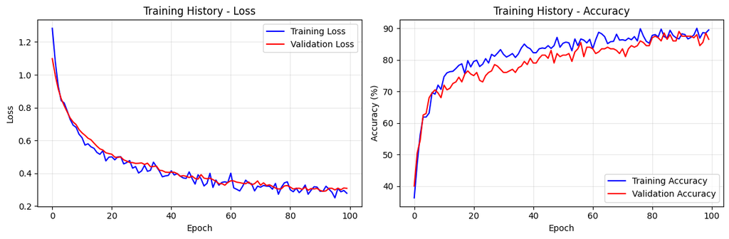

```
Final Validation Accuracy: 86.50%
```

```python
    train_loader = DataLoader(train_dataset, batch_size=32, shuffle=True)
    val_loader = DataLoader(val_dataset, batch_size=32, shuffle=False)

    # 3. Create MLP model
    model = MLP(
        input_size=n_features,
        hidden_sizes=[64, 32, 16],
        output_size=n_classes,
        activation='relu',
        dropout_rate=0.1,
        use_batch_norm=True
    )

    # Print model architecture
    arch_info = model.get_architecture_info()
    print(f"\nModel Architecture: {arch_info['architecture']}")
    print(f"Total Parameters: {arch_info['total_parameters']:,}")
    print(f"Depth: {arch_info['depth']} layers")
    print(f"Max Width: {arch_info['width']} neurons")

    # 4. Train the model
    trainer = MLPTrainer(model)

    print(f"\nStarting training...")
    trainer.train(
        train_loader=train_loader,
        val_loader=val_loader,
        epochs=100,
        lr=0.001,
        optimizer_name='adam',
        criterion_name='cross_entropy',
        patience=15,
        verbose=True
    )

    # 5. Plot training history
    trainer.plot_training_history()

    # 6. Final evaluation
    with torch.no_grad():
        model.eval()
        val_predictions = []
        val_targets = []

        for batch_x, batch_y in val_loader:
            outputs = model(batch_x)
            _, predicted = torch.max(outputs, 1)
            val_predictions.extend(predicted.cpu().numpy())
            val_targets.extend(batch_y.cpu().numpy())

        accuracy = 100 * np.mean(np.array(val_predictions) == np.array(val_targets))
        print(f"\nFinal Validation Accuracy: {accuracy:.2f}%")

    return model, trainer, arch_info

# Run the main demo
if __name__ == "__main__":
    trained_model, trainer, model_info = main_mlp_demo()
```

## Advanced MLP Concepts

### Architectural Considerations

**Depth vs Width Trade-offs:**

- **Deep Networks**: Better feature hierarchies, more expressive
- **Wide Networks**: More parallel processing, fewer vanishing gradient issues
- **Optimal Balance**: Depends on data complexity and computational constraints

### Modern MLP Variants

1. **Residual MLPs**: Skip connections for deeper training
2. **MLP-Mixer**: Pure MLP architecture for vision tasks
3. **FeedForward Networks in Transformers**: Key component of attention mechanisms
4. **Gated Linear Units (GLU)**: Gating mechanisms in MLPs

### Training Challenges & Solutions

| **Challenge** | **Problem** | **Solution** |
| --- | --- | --- |
| **Vanishing Gradients** | Deep networks hard to train | Skip connections, better initialization |
| **Overfitting** | Poor generalization | Dropout, batch normalization, regularization |
| **Dead ReLUs** | Neurons never activate | Leaky ReLU, ELU, proper initialization |
| **Internal Covariate Shift** | Layer input distributions change | Batch/Layer normalization |

### Connection to Other Components

MLPs serve as fundamental building blocks in:

- **CNNs**: Final classification layers
- **RNNs**: Hidden state transformations
- **Transformers**: Feed-forward networks in each layer
- **GANs**: Both generator and discriminator networks
- **Autoencoders**: Encoder and decoder networks

## Next Steps & Related Components

### Building on MLPs

Now that you understand MLPs, explore how they connect to other neural network components:

1. **Activation Functions** - Deep dive into non-linearities that make MLPs powerful
2. **Artificial Neurons** - Understand the fundamental building blocks
3. **Convolution Operations** - See how CNNs extend MLPs for spatial data
4. **Attention Mechanisms** - Learn how Transformers use MLPs in attention layers

### Advanced Topics to Explore

- **Initialization Strategies**: Xavier, He, and other initialization schemes
- **Regularization Techniques**: L1/L2 regularization, dropout variants
- **Optimization**: Adam, RMSprop, and advanced optimizers
- **Architecture Search**: AutoML for finding optimal MLP designs
- **Pruning & Compression**: Making MLPs more efficient

### Modern Applications

MLPs remain relevant in modern deep learning:

- **Transformer Feed-Forward Networks**: Core component of GPT, BERT
- **MLP-Mixer**: Pure MLP architecture for computer vision
- **Implicit Neural Representations**: MLPs for continuous signal representation
- **Neural ODEs**: MLPs as continuous-time dynamical systems

### Key Takeaways

✅ **MLPs are universal function approximators** - Can learn any continuous mapping with sufficient capacity

✅ **Depth enables hierarchy** - Multiple layers learn increasingly complex features

✅ **Width provides capacity** - More neurons per layer increase expressive power

✅ **Regularization is crucial** - Modern techniques prevent overfitting in large MLPs

✅ **Foundation for everything** - Nearly all neural architectures use MLP components

MLPs form the backbone of deep learning - understanding them deeply will help you master any neural network architecture!